# assignment 3

2023-03-16

```r
suppressPackageStartupMessages({
  library(AnnotationHub)
  library(Rsubread)
  library(rtracklayer)
  library(Biostrings)
  library(Rfastp)
  library(epiwraps)
})
ah <- AnnotationHub()
```

```
## snapshotDate(): 2022-10-31
```

We will perform the primary analysis of an example dataset, at each step demonstrating the use of both a very standard pipeline, and a full R-based equivalent. Pay attention to which chunks are R or bash code (see header)

# Downloading the raw reads

```r
dir.create("raw")
download.file("https://www.encodeproject.org/files/ENCFF127RRR/@@download/ENCFF127RRR.fastq.gz", dest="raw/CTCF.fastq.gz")
```

### Building a genome index for mapping

```r
# we get the genome sequence from AnnotationHub
genome <- ah[["AH49674"]]
# we create a new directory that will contain the genome index
dir.create("BDGP6_genome")
# we write the genome sequence in fasta format
export(import.2bit(genome), "BDGP6_genome/genome.fasta.gz", compress=TRUE)
# we build a Rsubread index
Rsubread::buildindex("BDGP6_genome/rsubread", reference="BDGP6_genome/genome.fasta.gz")
```

```r
dir.create("aligned")
getwd()
```

```
## [1] "/Users/julianortner/Desktop/Master MHS/8. Semester (Master MHS)/Excelsius"
```

# Alignment of reads

```r
align.stats <- Rsubread::align(index="BDGP6_genome/rsubread", type="dna",
                               readfile1=c("raw/CTCF.fastq.gz/"),
                               output_file=c("aligned/CTCF.bam"),
                               nthreads=6, sortReadsByCoordinates=TRUE)
align.stats
```

[output not shown]

Based on the alignment output, there is a total of 3,884,614 reads and 3,515,416 of those reads were mapped, which corresponds to 90.5% of the total reads. Out of the mapped reads, 3,057,440 were uniquely mapped and 457,976 were multi-mapped.

These numbers provide a quantitative measure of the success of the alignment step, and the high mapping rate suggests that the data quality is good.

However, it is worth noting that multi-mapping reads can be a potential source of ambiguity and may need to be further examined in downstream analyses.

```r
peaks <- callPeaks("aligned/CTCF.bam", fragLength=50L)
```

```
## Reading signal and identifying candidate regions...
```

```
## Reading signal coverage...
```

```
## 44177 initial candidate regions
```

```
## Getting strand information
```

```
## 11139 peaks after filtering
```

```
## Reading signal coverage...
```

```
## 24129 initial candidate regions
```

```
## Getting strand information
```

```
## 5784 peaks after filtering
```

```
## Reading signal coverage...
```

```
## 23692 initial candidate regions
```

```
## Getting strand information
```

```
## 5955 peaks after filtering
```

```
## Reading signal coverage...
```

```
## 15693 initial candidate regions
```

```
## Getting strand information
```

```
## 4038 peaks after filtering
```

```
## Identified 26916 candidate regions
```

```
## Computing significance...
```

```
## (In the absence of a control, FDR is unlikely to be calibrated)
```

```
## Reporting 2873 regions, 1622 with FDR<0.05
```

```r
# if we want to save it as a bed file:
dir.create("peaks")
rtracklayer::export.bed(peaks, "peaks/peaks.bed")
```

The function reported a total of 2873 regions, with 1622 having a false discovery rate (FDR) of less than 0.05.

The output gives a total of 2873 candidate regions with potential enrichment of CTCF binding, and the identified peaks can be further examined in downstream analyses.

```r
peaks
```

```
## GRanges object with 2873 ranges and 9 metadata columns:
##                 seqnames    ranges strand |  maxCount meanCount    maxPos
##                    <Rle> <IRanges>  <Rle> | <integer> <numeric> <integer>
##      [1]              2L 1647-1674      * |        14        14         9
##      [2]              2L 1799-1824      * |        15        15         8
##      [3]              2L 3148-3174      * |        25        25        11
##      [4]              2L 3599-3625      * |        27        27        12
##      [5]              2L 4048-4075      * |        21        21        13
##      ...             ...       ...    ... .       ...       ...       ...
##   [2869] 211000022278635   766-793      * |        15   14.9286         6
##   [2870] 211000022278669   294-320      * |        15   14.1111         5
##   [2871] 211000022278669   403-427      * |        12   12.0000         5
##   [2872] 211000022278811    78-104      * |        38   38.0000        26
##   [2873] 211000022278137    97-118      * |      6860 6856.6818      6382
##             maxNeg        bg   log10FE    log10p  log10FDR     score
##          <integer> <numeric> <integer> <numeric> <numeric> <integer>
##      [1]         5   1.64775        75      3.23      0.00       493
##      [2]         7   1.68360        78      4.99      0.59       513
##      [3]        14   1.56642       101      9.08      4.67       664
##      [4]        15   1.53083       104     10.20      5.78       684
##      [5]         8   1.54288        94      5.95      1.54       618
##      ...       ...       ...       ...       ...       ...       ...
##   [2869]         7   3.04592        60      4.08      0.00       395
##   [2870]         8   1.98925        70      3.23      0.00       461
##   [2871]         7   1.98925        64      3.23      0.00       421
##   [2872]        12   2.58706       104     10.20      5.78       684
##   [2873]       457 367.43028       127       Inf       Inf       836
##   -------
##   seqinfo: 1870 sequences from an unspecified genome; no seqlengths
```

```r
sorted_peaks <- peaks[order(peaks$log10FE, decreasing = TRUE), ]
region <- as.character(granges(peaks[812]))
# specifies the genomic coordinates of the peak of interest in the format chromosome:start-end
region # 3R:14391367-14391483
```

```
## [1] "3R:12980796-12981199"
```

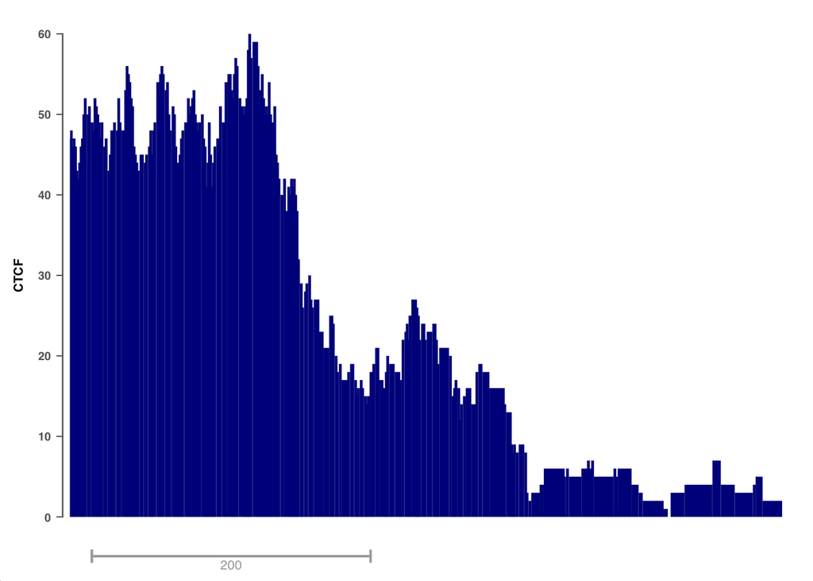

```r
# plot the signal around a specific peak of interest in the ChIP-seq data and visualize the read coverage across the region.
plotSignalTracks(c(CTCF="aligned/CTCF.bam"), region=region)
```

```r
region_spec <- "3R:28442014-28442089"
region_spec
```

```
## [1] "3R:28442014-28442089"
```

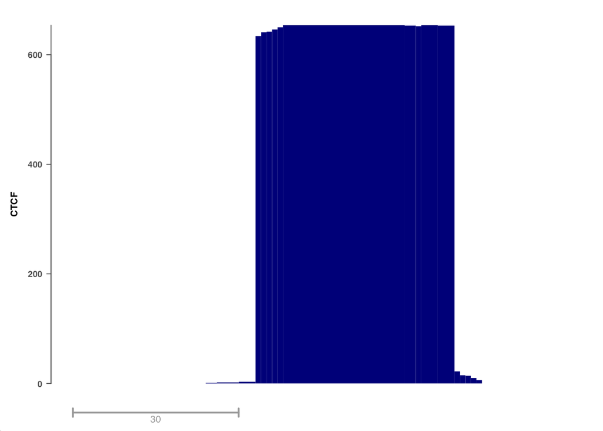

```r
plotSignalTracks(c(CTCF="aligned/CTCF.bam"), region=region_spec)
```

Signal is enriched comapred to it’s background but also could be an artefact.